# Risk Factor Analysis

## Outcome Variable

**Outcome Variable:** whz

## Predictor Variables

**Intervention Variable:** hhwealth_quart

**Adjustment Set:**

unadjusted

## Stratifying Variables

The analysis was stratified on these variable(s):

- agecat
- studyid
- country

## Data Summary

| agecat | studyid | country | hhwealth_quart | n_cell | n |
| --- | --- | --- | --- | --- | --- |
| Birth | ki0047075b-MAL-ED | BANGLADESH | Wealth Q4 | 56 | 201 |
| Birth | ki0047075b-MAL-ED | BANGLADESH | Wealth Q1 | 48 | 201 |
| Birth | ki0047075b-MAL-ED | BANGLADESH | Wealth Q2 | 46 | 201 |
| Birth | ki0047075b-MAL-ED | BANGLADESH | Wealth Q3 | 51 | 201 |
| Birth | ki0047075b-MAL-ED | BRAZIL | Wealth Q4 | 10 | 57 |
| Birth | ki0047075b-MAL-ED | BRAZIL | Wealth Q1 | 20 | 57 |
| Birth | ki0047075b-MAL-ED | BRAZIL | Wealth Q2 | 16 | 57 |
| Birth | ki0047075b-MAL-ED | BRAZIL | Wealth Q3 | 11 | 57 |
| Birth | ki0047075b-MAL-ED | INDIA | Wealth Q4 | 8 | 39 |
| Birth | ki0047075b-MAL-ED | INDIA | Wealth Q1 | 13 | 39 |
| Birth | ki0047075b-MAL-ED | INDIA | Wealth Q2 | 9 | 39 |
| Birth | ki0047075b-MAL-ED | INDIA | Wealth Q3 | 9 | 39 |
| Birth | ki0047075b-MAL-ED | NEPAL | Wealth Q4 | 6 | 25 |
| Birth | ki0047075b-MAL-ED | NEPAL | Wealth Q1 | 8 | 25 |
| Birth | ki0047075b-MAL-ED | NEPAL | Wealth Q2 | 3 | 25 |
| Birth | ki0047075b-MAL-ED | NEPAL | Wealth Q3 | 8 | 25 |
| Birth | ki0047075b-MAL-ED | PERU | Wealth Q4 | 53 | 210 |
| Birth | ki0047075b-MAL-ED | PERU | Wealth Q1 | 55 | 210 |
| Birth | ki0047075b-MAL-ED | PERU | Wealth Q2 | 51 | 210 |
| Birth | ki0047075b-MAL-ED | PERU | Wealth Q3 | 51 | 210 |
| Birth | ki0047075b-MAL-ED | SOUTH AFRICA | Wealth Q4 | 17 | 95 |
| Birth | ki0047075b-MAL-ED | SOUTH AFRICA | Wealth Q1 | 26 | 95 |
| Birth | ki0047075b-MAL-ED | SOUTH AFRICA | Wealth Q2 | 24 | 95 |
| Birth | ki0047075b-MAL-ED | SOUTH AFRICA | Wealth Q3 | 28 | 95 |
| Birth | ki0047075b-MAL-ED | TANZANIA, UNITED REPUBLIC OF | Wealth Q4 | 23 | 112 |
| Birth | ki0047075b-MAL-ED | TANZANIA, UNITED REPUBLIC OF | Wealth Q1 | 26 | 112 |
| Birth | ki0047075b-MAL-ED | TANZANIA, UNITED REPUBLIC OF | Wealth Q2 | 30 | 112 |
| Birth | ki0047075b-MAL-ED | TANZANIA, UNITED REPUBLIC OF | Wealth Q3 | 33 | 112 |
| Birth | ki1000108-CMC-V-BCS-2002 | INDIA | Wealth Q4 | 32 | 86 |
| Birth | ki1000108-CMC-V-BCS-2002 | INDIA | Wealth Q1 | 13 | 86 |

[output cut: 178 more lines]

The following strata were considered:

- agecat: 24 months, studyid: ki0047075b-MAL-ED, country: BANGLADESH
- agecat: 24 months, studyid: ki0047075b-MAL-ED, country: BRAZIL
- agecat: 24 months, studyid: ki0047075b-MAL-ED, country: INDIA
- agecat: 24 months, studyid: ki0047075b-MAL-ED, country: NEPAL
- agecat: 24 months, studyid: ki0047075b-MAL-ED, country: PERU
- agecat: 24 months, studyid: ki0047075b-MAL-ED, country: SOUTH AFRICA
- agecat: 24 months, studyid: ki0047075b-MAL-ED, country: TANZANIA, UNITED REPUBLIC OF
- agecat: 24 months, studyid: ki1000108-CMC-V-BCS-2002, country: INDIA
- agecat: 24 months, studyid: ki1000108-IRC, country: INDIA
- agecat: 24 months, studyid: ki1017093b-PROVIDE, country: BANGLADESH
- agecat: 24 months, studyid: ki1066203-TanzaniaChild2, country: TANZANIA, UNITED REPUBLIC OF
- agecat: 24 months, studyid: ki1113344-GMS-Nepal, country: NEPAL
- agecat: 24 months, studyid: ki1114097-CONTENT, country: PERU
- agecat: 24 months, studyid: ki1135781-COHORTS, country: GUATEMALA
- agecat: 24 months, studyid: ki1135781-COHORTS, country: PHILIPPINES
- agecat: 24 months, studyid: ki1148112-LCNI-5, country: MALAWI
- agecat: 24 months, studyid: kiGH5241-JiVitA-3, country: BANGLADESH
- agecat: 24 months, studyid: kiGH5241-JiVitA-4, country: BANGLADESH
- agecat: 6 months, studyid: ki0047075b-MAL-ED, country: BANGLADESH
- agecat: 6 months, studyid: ki0047075b-MAL-ED, country: BRAZIL
- agecat: 6 months, studyid: ki0047075b-MAL-ED, country: INDIA
- agecat: 6 months, studyid: ki0047075b-MAL-ED, country: NEPAL
- agecat: 6 months, studyid: ki0047075b-MAL-ED, country: PERU
- agecat: 6 months, studyid: ki0047075b-MAL-ED, country: SOUTH AFRICA
- agecat: 6 months, studyid: ki0047075b-MAL-ED, country: TANZANIA, UNITED REPUBLIC OF
- agecat: 6 months, studyid: ki1000108-CMC-V-BCS-2002, country: INDIA
- agecat: 6 months, studyid: ki1000108-IRC, country: INDIA
- agecat: 6 months, studyid: ki1017093b-PROVIDE, country: BANGLADESH
- agecat: 6 months, studyid: ki1066203-TanzaniaChild2, country: TANZANIA, UNITED REPUBLIC OF
- agecat: 6 months, studyid: ki1113344-GMS-Nepal, country: NEPAL
- agecat: 6 months, studyid: ki1114097-CONTENT, country: PERU
- agecat: 6 months, studyid: ki1135781-COHORTS, country: GUATEMALA
- agecat: 6 months, studyid: ki1135781-COHORTS, country: PHILIPPINES
- agecat: 6 months, studyid: ki1148112-LCNI-5, country: MALAWI
- agecat: 6 months, studyid: kiGH5241-JiVitA-3, country: BANGLADESH
- agecat: 6 months, studyid: kiGH5241-JiVitA-4, country: BANGLADESH
- agecat: Birth, studyid: ki0047075b-MAL-ED, country: BANGLADESH
- agecat: Birth, studyid: ki0047075b-MAL-ED, country: BRAZIL
- agecat: Birth, studyid: ki0047075b-MAL-ED, country: INDIA
- agecat: Birth, studyid: ki0047075b-MAL-ED, country: NEPAL
- agecat: Birth, studyid: ki0047075b-MAL-ED, country: PERU
- agecat: Birth, studyid: ki0047075b-MAL-ED, country: SOUTH AFRICA
- agecat: Birth, studyid: ki0047075b-MAL-ED, country: TANZANIA, UNITED REPUBLIC OF
- agecat: Birth, studyid: ki1000108-CMC-V-BCS-2002, country: INDIA
- agecat: Birth, studyid: ki1000108-IRC, country: INDIA
- agecat: Birth, studyid: ki1017093b-PROVIDE, country: BANGLADESH
- agecat: Birth, studyid: ki1113344-GMS-Nepal, country: NEPAL
- agecat: Birth, studyid: ki1114097-CONTENT, country: PERU
- agecat: Birth, studyid: ki1135781-COHORTS, country: GUATEMALA
- agecat: Birth, studyid: ki1135781-COHORTS, country: PHILIPPINES
- agecat: Birth, studyid: kiGH5241-JiVitA-3, country: BANGLADESH
- agecat: Birth, studyid: kiGH5241-JiVitA-4, country: BANGLADESH

### Dropped Strata

Some strata were dropped due to rare outcomes:

- agecat: Birth, studyid: ki0047075b-MAL-ED, country: NEPAL
- agecat: Birth, studyid: ki1114097-CONTENT, country: PERU
- agecat: 24 months, studyid: ki1066203-TanzaniaChild2, country: TANZANIA, UNITED REPUBLIC OF

## Methods Detail

We’re interested in the causal parameters $E[Y_a]$ for all values of $a \in \mathcal{A}$. These parameters represent the mean outcome if, possibly contrary to fact, we intervened to set all units to have $A=a$. Under the randomization and positivity assumptions, these are identified by the statistical parameters $\psi_a=E_W[E_{Y|A,W}(Y|A=a,W)]$. In addition, we’re interested in the mean of $Y$, $E[Y]$ under no intervention (the observed mean). We will estimate these parameters by using SuperLearner to fit the relevant likelihood factors – $E_{Y|A,W}(Y|A=a,W)$ and $p(A=a|W)$, and then updating our likelihood fit using a joint TMLE.

For unadjusted analyses ($W=\{\}$), initial likelihoods were estimated using Lrnr_glm to estimate the simple $E(Y|A)$ and Lrnr_mean to estimate $p(A)$. For adjusted analyses, a small library containing Lrnr_glmnet, Lrnr_xgboost, and Lrnr_mean was used.

Having estimated these parameters, we will then use the delta method to estimate relative risks and attributable risks relative to a prespecified baseline level of $A$.

# Results Detail

## Results Plots

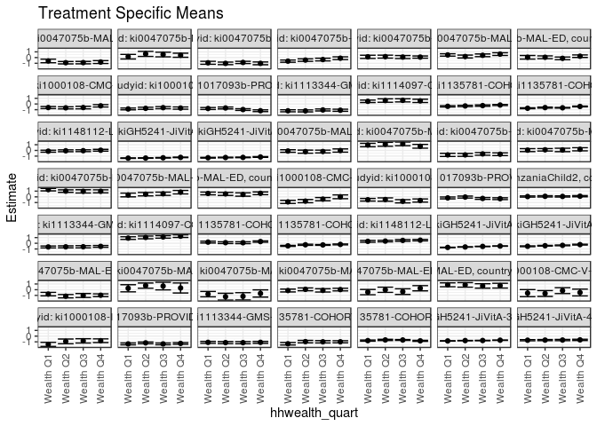

[figure not shown]

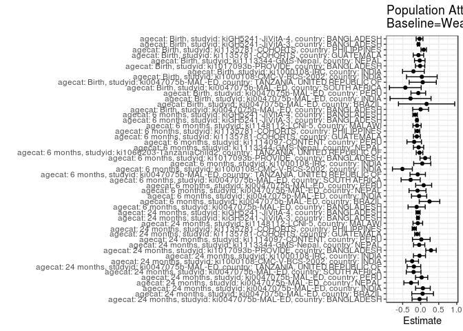

## Results Table

### Parameter: TSM

| agecat | studyid | country | intervention_level | baseline_level | estimate | ci_lower | ci_upper |
| --- | --- | --- | --- | --- | --- | --- | --- |
| Birth | ki0047075b-MAL-ED | BANGLADESH | Wealth Q4 | NA | -0.9708036 | -1.2125533 | -0.7290539 |
| Birth | ki0047075b-MAL-ED | BANGLADESH | Wealth Q1 | NA | -0.7736458 | -1.0748823 | -0.4724094 |
| Birth | ki0047075b-MAL-ED | BANGLADESH | Wealth Q2 | NA | -1.1367391 | -1.4296771 | -0.8438012 |
| Birth | ki0047075b-MAL-ED | BANGLADESH | Wealth Q3 | NA | -1.0147059 | -1.3593361 | -0.6700757 |
| Birth | ki0047075b-MAL-ED | BRAZIL | Wealth Q4 | NA | 0.3010000 | -0.5771574 | 1.1791574 |
| Birth | ki0047075b-MAL-ED | BRAZIL | Wealth Q1 | NA | 0.2500000 | -0.3735997 | 0.8735997 |
| Birth | ki0047075b-MAL-ED | BRAZIL | Wealth Q2 | NA | 0.7162500 | 0.2582356 | 1.1742644 |
| Birth | ki0047075b-MAL-ED | BRAZIL | Wealth Q3 | NA | 0.6363636 | -0.0317059 | 1.3044332 |
| Birth | ki0047075b-MAL-ED | INDIA | Wealth Q4 | NA | -0.6625000 | -1.2946579 | -0.0303421 |
| Birth | ki0047075b-MAL-ED | INDIA | Wealth Q1 | NA | -0.7753846 | -1.2462747 | -0.3044945 |
| Birth | ki0047075b-MAL-ED | INDIA | Wealth Q2 | NA | -1.2233333 | -1.8175527 | -0.6291139 |
| Birth | ki0047075b-MAL-ED | INDIA | Wealth Q3 | NA | -1.1588889 | -1.7968865 | -0.5208913 |
| Birth | ki0047075b-MAL-ED | PERU | Wealth Q4 | NA | 0.0196226 | -0.2069488 | 0.2461941 |
| Birth | ki0047075b-MAL-ED | PERU | Wealth Q1 | NA | -0.1434545 | -0.3914073 | 0.1044983 |
| Birth | ki0047075b-MAL-ED | PERU | Wealth Q2 | NA | 0.0627451 | -0.1855766 | 0.3110668 |
| Birth | ki0047075b-MAL-ED | PERU | Wealth Q3 | NA | -0.1211765 | -0.4088065 | 0.1664536 |
| Birth | ki0047075b-MAL-ED | SOUTH AFRICA | Wealth Q4 | NA | 0.2529412 | -0.2033447 | 0.7092270 |
| Birth | ki0047075b-MAL-ED | SOUTH AFRICA | Wealth Q1 | NA | -0.4207692 | -0.8857319 | 0.0441935 |
| Birth | ki0047075b-MAL-ED | SOUTH AFRICA | Wealth Q2 | NA | -0.0137500 | -0.4691436 | 0.4416436 |
| Birth | ki0047075b-MAL-ED | SOUTH AFRICA | Wealth Q3 | NA | -0.3378571 | -0.8371677 | 0.1614534 |
| Birth | ki0047075b-MAL-ED | TANZANIA, UNITED REPUBLIC OF | Wealth Q4 | NA | 0.7069565 | 0.2887216 | 1.1251914 |
| Birth | ki0047075b-MAL-ED | TANZANIA, UNITED REPUBLIC OF | Wealth Q1 | NA | 0.8576923 | 0.5122068 | 1.2031779 |
| Birth | ki0047075b-MAL-ED | TANZANIA, UNITED REPUBLIC OF | Wealth Q2 | NA | 0.8413333 | 0.4437596 | 1.2389071 |
| Birth | ki0047075b-MAL-ED | TANZANIA, UNITED REPUBLIC OF | Wealth Q3 | NA | 0.6587879 | 0.2709848 | 1.0465909 |
| Birth | ki1000108-CMC-V-BCS-2002 | INDIA | Wealth Q4 | NA | -0.4967187 | -1.0927927 | 0.0993552 |
| Birth | ki1000108-CMC-V-BCS-2002 | INDIA | Wealth Q1 | NA | -0.6023077 | -1.2239875 | 0.0193721 |
| Birth | ki1000108-CMC-V-BCS-2002 | INDIA | Wealth Q2 | NA | -0.6673684 | -1.1792476 | -0.1554892 |
| Birth | ki1000108-CMC-V-BCS-2002 | INDIA | Wealth Q3 | NA | -0.1622727 | -0.6759851 | 0.3514396 |
| Birth | ki1000108-IRC | INDIA | Wealth Q4 | NA | -0.8089873 | -1.1314135 | -0.4865611 |
| Birth | ki1000108-IRC | INDIA | Wealth Q1 | NA | -1.4476667 | -1.7995427 | -1.0957906 |

[output cut: 166 more lines]

### Parameter: E(Y)

| agecat | studyid | country | intervention_level | baseline_level | estimate | ci_lower | ci_upper |
| --- | --- | --- | --- | --- | --- | --- | --- |
| Birth | ki0047075b-MAL-ED | BANGLADESH | NA | NA | -0.9728358 | -1.1217009 | -0.8239707 |
| Birth | ki0047075b-MAL-ED | BRAZIL | NA | NA | 0.4643860 | 0.1360519 | 0.7927200 |
| Birth | ki0047075b-MAL-ED | INDIA | NA | NA | -0.9441026 | -1.2397919 | -0.6484132 |
| Birth | ki0047075b-MAL-ED | PERU | NA | NA | -0.0468095 | -0.1738806 | 0.0802616 |
| Birth | ki0047075b-MAL-ED | SOUTH AFRICA | NA | NA | -0.1729474 | -0.4186222 | 0.0727275 |
| Birth | ki0047075b-MAL-ED | TANZANIA, UNITED REPUBLIC OF | NA | NA | 0.7637500 | 0.5676177 | 0.9598823 |
| Birth | ki1000108-CMC-V-BCS-2002 | INDIA | NA | NA | -0.4648256 | -0.7643210 | -0.1653302 |
| Birth | ki1000108-IRC | INDIA | NA | NA | -1.0105831 | -1.1973019 | -0.8238643 |
| Birth | ki1017093b-PROVIDE | BANGLADESH | NA | NA | -1.2984586 | -1.3752758 | -1.2216415 |
| Birth | ki1113344-GMS-Nepal | NEPAL | NA | NA | -1.1164431 | -1.2040134 | -1.0288728 |
| Birth | ki1135781-COHORTS | GUATEMALA | NA | NA | -1.0572840 | -1.1606089 | -0.9539590 |
| Birth | ki1135781-COHORTS | PHILIPPINES | NA | NA | -0.7422912 | -0.7886598 | -0.6959226 |
| Birth | kiGH5241-JiVitA-3 | BANGLADESH | NA | NA | -0.7777103 | -0.7967006 | -0.7587201 |
| Birth | kiGH5241-JiVitA-4 | BANGLADESH | NA | NA | -0.6882498 | -0.7406539 | -0.6358456 |
| 6 months | ki0047075b-MAL-ED | BANGLADESH | NA | NA | -0.1333333 | -0.2623761 | -0.0042906 |
| 6 months | ki0047075b-MAL-ED | BRAZIL | NA | NA | 0.9720774 | 0.8078144 | 1.1363403 |
| 6 months | ki0047075b-MAL-ED | INDIA | NA | NA | -0.7102872 | -0.8371659 | -0.5834085 |
| 6 months | ki0047075b-MAL-ED | NEPAL | NA | NA | 0.1104308 | -0.0208643 | 0.2417259 |
| 6 months | ki0047075b-MAL-ED | PERU | NA | NA | 1.0512099 | 0.9285617 | 1.1738581 |
| 6 months | ki0047075b-MAL-ED | SOUTH AFRICA | NA | NA | 0.5404351 | 0.3867005 | 0.6941696 |
| 6 months | ki0047075b-MAL-ED | TANZANIA, UNITED REPUBLIC OF | NA | NA | 0.5362213 | 0.4049390 | 0.6675036 |
| 6 months | ki1000108-CMC-V-BCS-2002 | INDIA | NA | NA | -0.5026766 | -0.6536848 | -0.3516685 |
| 6 months | ki1000108-IRC | INDIA | NA | NA | -0.5989297 | -0.7344491 | -0.4634104 |
| 6 months | ki1017093b-PROVIDE | BANGLADESH | NA | NA | -0.1990907 | -0.2817968 | -0.1163845 |
| 6 months | ki1066203-TanzaniaChild2 | TANZANIA, UNITED REPUBLIC OF | NA | NA | 0.0801680 | 0.0273223 | 0.1330136 |
| 6 months | ki1113344-GMS-Nepal | NEPAL | NA | NA | -0.6038416 | -0.6899448 | -0.5177384 |
| 6 months | ki1114097-CONTENT | PERU | NA | NA | 1.0684318 | 0.9515274 | 1.1853362 |
| 6 months | ki1135781-COHORTS | GUATEMALA | NA | NA | 0.1914471 | 0.1185005 | 0.2643936 |
| 6 months | ki1135781-COHORTS | PHILIPPINES | NA | NA | -0.2938433 | -0.3352064 | -0.2524802 |
| 6 months | ki1148112-LCNI-5 | MALAWI | NA | NA | 0.4417647 | 0.3702742 | 0.5132552 |
| 6 months | kiGH5241-JiVitA-3 | BANGLADESH | NA | NA | -0.5932502 | -0.6127743 | -0.5737261 |
| 6 months | kiGH5241-JiVitA-4 | BANGLADESH | NA | NA | -0.3901595 | -0.4274150 | -0.3529041 |
| 24 months | ki0047075b-MAL-ED | BANGLADESH | NA | NA | -0.8192925 | -0.9412667 | -0.6973182 |
| 24 months | ki0047075b-MAL-ED | BRAZIL | NA | NA | 0.4626233 | 0.2567495 | 0.6684971 |
| 24 months | ki0047075b-MAL-ED | INDIA | NA | NA | -0.9516520 | -1.0670654 | -0.8362385 |
| 24 months | ki0047075b-MAL-ED | NEPAL | NA | NA | -0.3749123 | -0.4886073 | -0.2612173 |
| 24 months | ki0047075b-MAL-ED | PERU | NA | NA | 0.1111982 | -0.0118399 | 0.2342362 |
| 24 months | ki0047075b-MAL-ED | SOUTH AFRICA | NA | NA | 0.4090301 | 0.2879441 | 0.5301161 |
| 24 months | ki0047075b-MAL-ED | TANZANIA, UNITED REPUBLIC OF | NA | NA | 0.0547975 | -0.0703378 | 0.1799328 |
| 24 months | ki1000108-CMC-V-BCS-2002 | INDIA | NA | NA | -0.5571505 | -0.6585247 | -0.4557763 |
| 24 months | ki1000108-IRC | INDIA | NA | NA | -0.7458150 | -0.8368180 | -0.6548120 |
| 24 months | ki1017093b-PROVIDE | BANGLADESH | NA | NA | -0.8928670 | -0.9755153 | -0.8102187 |
| 24 months | ki1113344-GMS-Nepal | NEPAL | NA | NA | -1.1363107 | -1.2252817 | -1.0473398 |
| 24 months | ki1114097-CONTENT | PERU | NA | NA | 0.5668293 | 0.4302437 | 0.7034148 |
| 24 months | ki1135781-COHORTS | GUATEMALA | NA | NA | -0.2791396 | -0.3336899 | -0.2245893 |
| 24 months | ki1135781-COHORTS | PHILIPPINES | NA | NA | -0.6099592 | -0.6467541 | -0.5731643 |
| 24 months | ki1148112-LCNI-5 | MALAWI | NA | NA | -0.0477867 | -0.1301103 | 0.0345368 |
| 24 months | kiGH5241-JiVitA-3 | BANGLADESH | NA | NA | -1.2973086 | -1.3206115 | -1.2740057 |
| 24 months | kiGH5241-JiVitA-4 | BANGLADESH | NA | NA | -1.2231776 | -1.2550332 | -1.1913220 |

### Parameter: ATE

| agecat | studyid | country | intervention_level | baseline_level | estimate | ci_lower | ci_upper |
| --- | --- | --- | --- | --- | --- | --- | --- |
| Birth | ki0047075b-MAL-ED | BANGLADESH | Wealth Q4 | Wealth Q4 | 0.0000000 | 0.0000000 | 0.0000000 |
| Birth | ki0047075b-MAL-ED | BANGLADESH | Wealth Q1 | Wealth Q4 | 0.1971577 | -0.1890887 | 0.5834042 |
| Birth | ki0047075b-MAL-ED | BANGLADESH | Wealth Q2 | Wealth Q4 | -0.1659356 | -0.5457454 | 0.2138743 |
| Birth | ki0047075b-MAL-ED | BANGLADESH | Wealth Q3 | Wealth Q4 | -0.0439023 | -0.4648689 | 0.3770643 |
| Birth | ki0047075b-MAL-ED | BRAZIL | Wealth Q4 | Wealth Q4 | 0.0000000 | 0.0000000 | 0.0000000 |
| Birth | ki0047075b-MAL-ED | BRAZIL | Wealth Q1 | Wealth Q4 | -0.0510000 | -1.1280502 | 1.0260502 |
| Birth | ki0047075b-MAL-ED | BRAZIL | Wealth Q2 | Wealth Q4 | 0.4152500 | -0.5751730 | 1.4056730 |
| Birth | ki0047075b-MAL-ED | BRAZIL | Wealth Q3 | Wealth Q4 | 0.3353636 | -0.7680299 | 1.4387572 |
| Birth | ki0047075b-MAL-ED | INDIA | Wealth Q4 | Wealth Q4 | 0.0000000 | 0.0000000 | 0.0000000 |
| Birth | ki0047075b-MAL-ED | INDIA | Wealth Q1 | Wealth Q4 | -0.1128846 | -0.9011492 | 0.6753800 |
| Birth | ki0047075b-MAL-ED | INDIA | Wealth Q2 | Wealth Q4 | -0.5608333 | -1.4284279 | 0.3067612 |
| Birth | ki0047075b-MAL-ED | INDIA | Wealth Q3 | Wealth Q4 | -0.4963889 | -1.3945340 | 0.4017562 |
| Birth | ki0047075b-MAL-ED | PERU | Wealth Q4 | Wealth Q4 | 0.0000000 | 0.0000000 | 0.0000000 |
| Birth | ki0047075b-MAL-ED | PERU | Wealth Q1 | Wealth Q4 | -0.1630772 | -0.4989569 | 0.1728026 |
| Birth | ki0047075b-MAL-ED | PERU | Wealth Q2 | Wealth Q4 | 0.0431225 | -0.2930297 | 0.3792746 |
| Birth | ki0047075b-MAL-ED | PERU | Wealth Q3 | Wealth Q4 | -0.1407991 | -0.5069489 | 0.2253507 |
| Birth | ki0047075b-MAL-ED | SOUTH AFRICA | Wealth Q4 | Wealth Q4 | 0.0000000 | 0.0000000 | 0.0000000 |
| Birth | ki0047075b-MAL-ED | SOUTH AFRICA | Wealth Q1 | Wealth Q4 | -0.6737104 | -1.3251604 | -0.0222604 |
| Birth | ki0047075b-MAL-ED | SOUTH AFRICA | Wealth Q2 | Wealth Q4 | -0.2666912 | -0.9113462 | 0.3779639 |
| Birth | ki0047075b-MAL-ED | SOUTH AFRICA | Wealth Q3 | Wealth Q4 | -0.5907983 | -1.2671915 | 0.0855949 |
| Birth | ki0047075b-MAL-ED | TANZANIA, UNITED REPUBLIC OF | Wealth Q4 | Wealth Q4 | 0.0000000 | 0.0000000 | 0.0000000 |
| Birth | ki0047075b-MAL-ED | TANZANIA, UNITED REPUBLIC OF | Wealth Q1 | Wealth Q4 | 0.1507358 | -0.3917406 | 0.6932122 |
| Birth | ki0047075b-MAL-ED | TANZANIA, UNITED REPUBLIC OF | Wealth Q2 | Wealth Q4 | 0.1343768 | -0.4426720 | 0.7114256 |
| Birth | ki0047075b-MAL-ED | TANZANIA, UNITED REPUBLIC OF | Wealth Q3 | Wealth Q4 | -0.0481686 | -0.6185296 | 0.5221923 |
| Birth | ki1000108-CMC-V-BCS-2002 | INDIA | Wealth Q4 | Wealth Q4 | 0.0000000 | 0.0000000 | 0.0000000 |
| Birth | ki1000108-CMC-V-BCS-2002 | INDIA | Wealth Q1 | Wealth Q4 | -0.1055889 | -0.9668612 | 0.7556833 |
| Birth | ki1000108-CMC-V-BCS-2002 | INDIA | Wealth Q2 | Wealth Q4 | -0.1706497 | -0.9563496 | 0.6150503 |
| Birth | ki1000108-CMC-V-BCS-2002 | INDIA | Wealth Q3 | Wealth Q4 | 0.3344460 | -0.4524495 | 1.1213415 |
| Birth | ki1000108-IRC | INDIA | Wealth Q4 | Wealth Q4 | 0.0000000 | 0.0000000 | 0.0000000 |
| Birth | ki1000108-IRC | INDIA | Wealth Q1 | Wealth Q4 | -0.6386793 | -1.1159375 | -0.1614211 |

[output cut: 166 more lines]

### Parameter: PAR

| agecat | studyid | country | intervention_level | baseline_level | estimate | ci_lower | ci_upper |
| --- | --- | --- | --- | --- | --- | --- | --- |
| Birth | ki0047075b-MAL-ED | BANGLADESH | Wealth Q4 | NA | -0.0020322 | -0.2212092 | 0.2171447 |
| Birth | ki0047075b-MAL-ED | BRAZIL | Wealth Q4 | NA | 0.1633860 | -0.6166019 | 0.9433738 |
| Birth | ki0047075b-MAL-ED | INDIA | Wealth Q4 | NA | -0.2816026 | -0.8500282 | 0.2868230 |
| Birth | ki0047075b-MAL-ED | PERU | Wealth Q4 | NA | -0.0664322 | -0.2703192 | 0.1374549 |
| Birth | ki0047075b-MAL-ED | SOUTH AFRICA | Wealth Q4 | NA | -0.4258885 | -0.8663887 | 0.0146116 |
| Birth | ki0047075b-MAL-ED | TANZANIA, UNITED REPUBLIC OF | Wealth Q4 | NA | 0.0567935 | -0.3194325 | 0.4330194 |
| Birth | ki1000108-CMC-V-BCS-2002 | INDIA | Wealth Q4 | NA | 0.0318932 | -0.3930648 | 0.4568511 |
| Birth | ki1000108-IRC | INDIA | Wealth Q4 | NA | -0.2015957 | -0.5031499 | 0.0999584 |
| Birth | ki1017093b-PROVIDE | BANGLADESH | Wealth Q4 | NA | -0.0166405 | -0.1461638 | 0.1128829 |
| Birth | ki1113344-GMS-Nepal | NEPAL | Wealth Q4 | NA | -0.0259462 | -0.1718313 | 0.1199389 |
| Birth | ki1135781-COHORTS | GUATEMALA | Wealth Q4 | NA | -0.0621289 | -0.2065173 | 0.0822595 |
| Birth | ki1135781-COHORTS | PHILIPPINES | Wealth Q4 | NA | 0.0835493 | 0.0081632 | 0.1589353 |
| Birth | kiGH5241-JiVitA-3 | BANGLADESH | Wealth Q4 | NA | -0.0620544 | -0.0919133 | -0.0321955 |
| Birth | kiGH5241-JiVitA-4 | BANGLADESH | Wealth Q4 | NA | -0.0318687 | -0.1258995 | 0.0621622 |
| 6 months | ki0047075b-MAL-ED | BANGLADESH | Wealth Q4 | NA | -0.1124590 | -0.3502026 | 0.1252845 |
| 6 months | ki0047075b-MAL-ED | BRAZIL | Wealth Q4 | NA | 0.2447818 | -0.0403317 | 0.5298952 |
| 6 months | ki0047075b-MAL-ED | INDIA | Wealth Q4 | NA | -0.0438748 | -0.2546755 | 0.1669259 |
| 6 months | ki0047075b-MAL-ED | NEPAL | Wealth Q4 | NA | -0.0884675 | -0.3236528 | 0.1467178 |
| 6 months | ki0047075b-MAL-ED | PERU | Wealth Q4 | NA | 0.0823542 | -0.1391216 | 0.3038300 |
| 6 months | ki0047075b-MAL-ED | SOUTH AFRICA | Wealth Q4 | NA | -0.2784897 | -0.5431801 | -0.0137993 |
| 6 months | ki0047075b-MAL-ED | TANZANIA, UNITED REPUBLIC OF | Wealth Q4 | NA | -0.0824030 | -0.2955988 | 0.1307928 |
| 6 months | ki1000108-CMC-V-BCS-2002 | INDIA | Wealth Q4 | NA | -0.5071503 | -0.7832770 | -0.2310236 |
| 6 months | ki1000108-IRC | INDIA | Wealth Q4 | NA | 0.0436203 | -0.1938960 | 0.2811365 |
| 6 months | ki1017093b-PROVIDE | BANGLADESH | Wealth Q4 | NA | 0.1239815 | -0.0196915 | 0.2676545 |
| 6 months | ki1066203-TanzaniaChild2 | TANZANIA, UNITED REPUBLIC OF | Wealth Q4 | NA | -0.0324301 | -0.1244301 | 0.0595698 |
| 6 months | ki1113344-GMS-Nepal | NEPAL | Wealth Q4 | NA | -0.0586511 | -0.2004262 | 0.0831239 |
| 6 months | ki1114097-CONTENT | PERU | Wealth Q4 | NA | -0.1803342 | -0.3815475 | 0.0208790 |
| 6 months | ki1135781-COHORTS | GUATEMALA | Wealth Q4 | NA | -0.1067535 | -0.2023421 | -0.0111649 |
| 6 months | ki1135781-COHORTS | PHILIPPINES | Wealth Q4 | NA | -0.0930369 | -0.1585540 | -0.0275197 |
| 6 months | ki1148112-LCNI-5 | MALAWI | Wealth Q4 | NA | -0.1004934 | -0.2141480 | 0.0131613 |
| 6 months | kiGH5241-JiVitA-3 | BANGLADESH | Wealth Q4 | NA | -0.1043254 | -0.1313334 | -0.0773174 |
| 6 months | kiGH5241-JiVitA-4 | BANGLADESH | Wealth Q4 | NA | -0.1545632 | -0.2171194 | -0.0920069 |
| 24 months | ki0047075b-MAL-ED | BANGLADESH | Wealth Q4 | NA | -0.0319974 | -0.2388599 | 0.1748652 |
| 24 months | ki0047075b-MAL-ED | BRAZIL | Wealth Q4 | NA | 0.0534723 | -0.2468822 | 0.3538269 |
| 24 months | ki0047075b-MAL-ED | INDIA | Wealth Q4 | NA | 0.0615684 | -0.1421581 | 0.2652948 |
| 24 months | ki0047075b-MAL-ED | NEPAL | Wealth Q4 | NA | -0.2658445 | -0.4665959 | -0.0650930 |
| 24 months | ki0047075b-MAL-ED | PERU | Wealth Q4 | NA | 0.0262110 | -0.1428805 | 0.1953025 |
| 24 months | ki0047075b-MAL-ED | SOUTH AFRICA | Wealth Q4 | NA | -0.1966842 | -0.4003917 | 0.0070234 |
| 24 months | ki0047075b-MAL-ED | TANZANIA, UNITED REPUBLIC OF | Wealth Q4 | NA | -0.1877422 | -0.3766600 | 0.0011757 |
| 24 months | ki1000108-CMC-V-BCS-2002 | INDIA | Wealth Q4 | NA | -0.2373962 | -0.4145641 | -0.0602282 |
| 24 months | ki1000108-IRC | INDIA | Wealth Q4 | NA | -0.0336483 | -0.2007385 | 0.1334418 |
| 24 months | ki1017093b-PROVIDE | BANGLADESH | Wealth Q4 | NA | 0.2859854 | 0.1406489 | 0.4313219 |
| 24 months | ki1113344-GMS-Nepal | NEPAL | Wealth Q4 | NA | -0.0424935 | -0.1990278 | 0.1140407 |
| 24 months | ki1114097-CONTENT | PERU | Wealth Q4 | NA | 0.0171951 | -0.2272798 | 0.2616700 |
| 24 months | ki1135781-COHORTS | GUATEMALA | Wealth Q4 | NA | -0.0977075 | -0.1666807 | -0.0287343 |
| 24 months | ki1135781-COHORTS | PHILIPPINES | Wealth Q4 | NA | -0.1772146 | -0.2356263 | -0.1188030 |
| 24 months | ki1148112-LCNI-5 | MALAWI | Wealth Q4 | NA | -0.0797222 | -0.2133451 | 0.0539006 |
| 24 months | kiGH5241-JiVitA-3 | BANGLADESH | Wealth Q4 | NA | -0.0762452 | -0.1110643 | -0.0414261 |
| 24 months | kiGH5241-JiVitA-4 | BANGLADESH | Wealth Q4 | NA | -0.0739021 | -0.1309267 | -0.0168775 |